# Lista 2

Luiz Eduardo Medeiros da Rocha

2023-06-16

```r
 # Install and load packages ----
 if (!require(install.load)) install.packages(install.load)
 install.load::install_load("tidyverse", "data.table","sfsmisc","MASS")
```

1. Crie uma amostra aleatória de 50 observações, normalmente distribuída, com média igual ao primeiro algarismo do seu número USP e desvio-padrão igual ao último algoritmo do seu número USP.

```r
 set.seed(14664824)

 LN_samp1 <- rnorm(50, 1, 4)
 LN_samp1
```

```
##  [1]  6.19066643  2.50296234  3.01863419 -6.28313596  7.00130567 -0.09615271
##  [7]  5.47406824 -3.64734501 -2.23337522 -1.31668698  1.72621770 -2.99083074
## [13]  0.77338395 -0.89232082  5.37047230  2.20750163 -4.05874388  7.71085929
## [19]  5.97245722  1.49979720  3.98506945 -1.52211812 -2.39657717  2.85628047
## [25]  5.90764290  4.78183893  6.05929497 -6.91206652 -3.55842428  4.59020117
## [31]  4.48579618  3.94862223 -0.75119401  5.70313197  2.58813810  1.09931440
## [37]  0.44704329  2.71613760  1.36399866  3.03300493  0.48777086  3.29806429
## [43]  4.30226049 -2.10727980  1.73184629 -0.04861126  0.03668107 -2.47093400
## [49] -6.39800435 -1.68071225
```

2. Crie uma função no R, com dois argumentos, um deles um vetor de parâmetros (média e desviopadrão), e outro o banco de dados. Esta função deve retornar o negativo da função log-verossimilhança para a amostra, avaliada para um valor do vetor de parâmetros e o banco de dados do item anterior.

```r
 loglike <- function(Theta, df){

   n <- length(df)

   loglik <- -n/2*log(2*pi) - n*log(Theta[2]) - sum((df-Theta[1])^2)/(2*Theta[2]^2)

   return(-loglik)

 }

 loglike(c(1,4), LN_samp1)
```

```
## [1] 136.0879
```

3. Faça um grá co mostrando o valor da função de verossimilhança para diferentes valores de média e desvio-padrão.

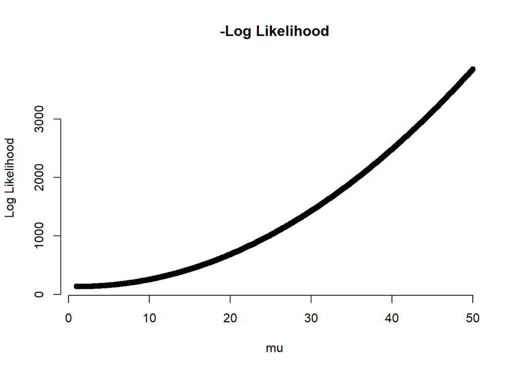

```r
 # Primeiro fixando o parâmetro sigma em 4 e plotando para um range de parâmetros mu

 loglike_mu <- function(mu, df){

   n <- length(df)

   loglik <- -n/2*log(2*pi) - n*log(4) - sum((df-mu)^2)/(2*4^2)

   return(-loglik)

 }

  range_mu <- seq(1, 50, length.out=500)

  llks_mu <- map(range_mu, loglike_mu, LN_samp1)

  plot(range_mu, llks_mu ,main = "-Log Likelihood",
       xlab = "mu", ylab = "Log Likelihood",
       pch = 19, frame = FALSE)
```

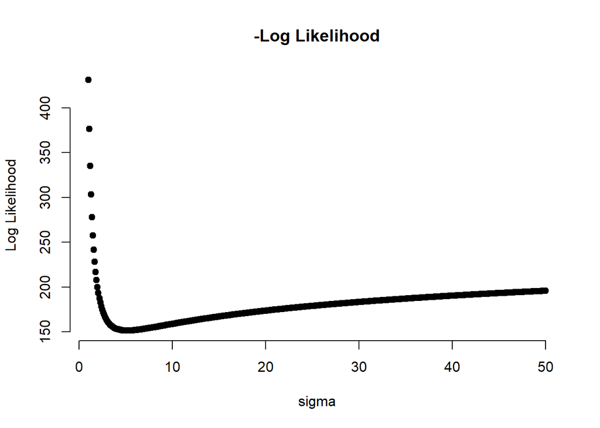

```r
 # Agora fazendo o mesmo porém fixando mu em 1 e variando sigma

  loglike_sigma <- function(sigma, df){

   n <- length(df)

   loglik <- -n/2*log(sigma*pi) - n*log(4) - sum((df-1)^2)/(2*sigma^2)

   return(-loglik)

 }

  range_sigma <- seq(1, 50, length.out=500)

  llks_sigma <- map(range_sigma, loglike_sigma, LN_samp1)

  plot(range_sigma, llks_sigma ,main = "-Log Likelihood",
       xlab = "sigma", ylab = "Log Likelihood",
       pch = 19, frame = FALSE)
```

4. Estime os valores da média e desvio-padrão para esta amostra, por meio da maximização da função verossimilhança escrita anteriormente.

```r
  start = c(2,3)

  Theta <- optim(start, loglike, df = LN_samp1,hessian = T, method = "BFGS")

  Theta$par
```

```
## [1] 1.270118 3.640858
```

5. Calcule a matriz de variância-covariância dos coeficientes para esta amostra. Podemos rejeitar a hipótese que esses coefientes são iguais aos valores que usamos pra criar a amostra no primeiro item?

```r
vcov <- solve(Theta$hessian)
vcov
```

```
##               [,1]          [,2]
## [1,]  2.651169e-01 -6.192794e-08
## [2,] -6.192794e-08  1.325584e-01
```

```r
  se <- sqrt(diag(vcov))

  t <- Theta$par/se

  pval <- 2*(1-pnorm(abs(t[[2]])))

  results <- cbind(Theta$par,se,t,pval)

  results
```

```
##                      se         t pval
## [1,] 1.270118 0.5148950  2.466752    0
## [2,] 3.640858 0.3640857 10.000001    0
```

6. Agora crie 100 amostras que nem a do primeiro item e faça um histograma das estimativas de média e desvio-padrão. Parece uma distribuição normal?

Sim, parece uma distribuição normal.

```r
    sampi <- replicate(100, rnorm(50, 1, 4)) %>% as_tibble()


    f <- function(i){
      b <- sampi %>%
      pivot_longer(cols = V1:V100) %>%
      group_by(name) %>%
      group_nest() %>%
      slice(i) %>%
      unnest() %>%
      dplyr::select(value) %>%
      as_vector()

     R <- optim(start, loglike, df = b, method = "BFGS")

      matrix(R$par, ncol=2)
    }

     R <- map(1:100, f)

     datah1 <-
       do.call(rbind, R) %>%
       as_tibble() %>%
       print(n=100)
```

```
## # A tibble: 100 × 2
##          V1    V2
##       <dbl> <dbl>
##   1  0.563   3.92
##   2  1.88    3.33
##   3  1.23    3.92
##   4  0.833   4.75
##   5  0.794   3.86
##   6  1.47    4.06
##   7  0.506   4.27
##   8  1.77    4.65
##   9  1.82    3.82
##  10  0.882   4.06
##  11  0.855   3.51
##  12  0.104   4.26
```

[output cut: 88 more lines]

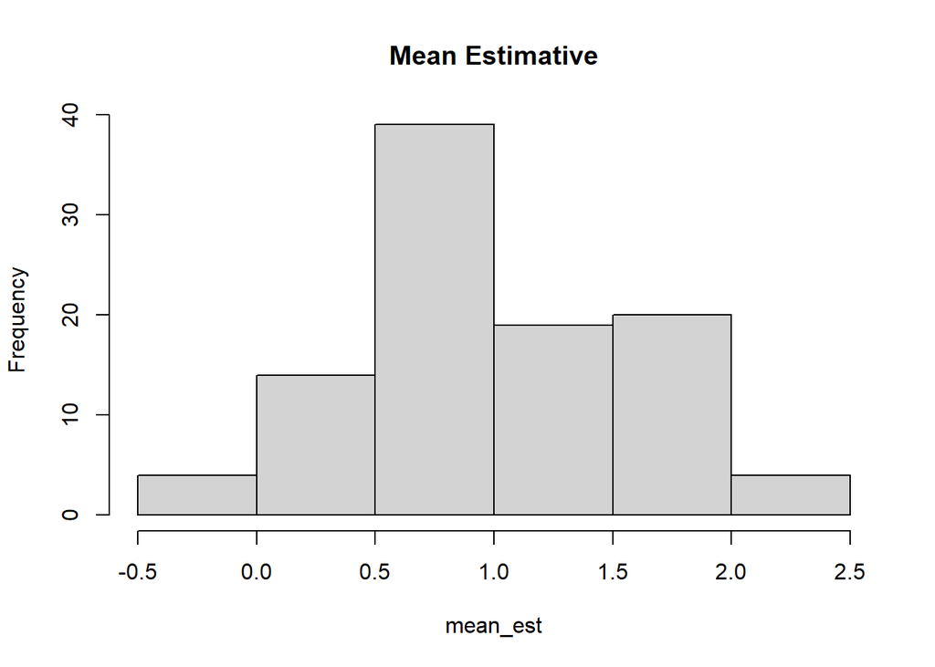

```r
    hist(datah1$V1, main = "Mean Estimative", xlab = "mean_est")
```

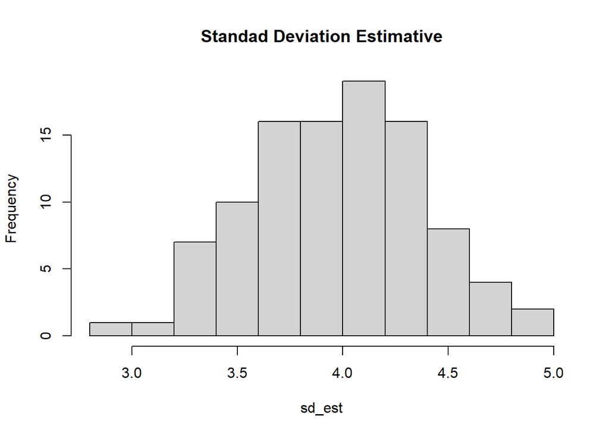

```r
    hist(datah1$V2, main = "Standad Deviation Estimative",
         xlab = "sd_est")
```

7. Agora crie 1000 amostras e faça histogramas das estimativas de média e desvio-padrão. Parece uma distribuição normal? Teste formalmente (descubra qual é o teste formal pra isso).

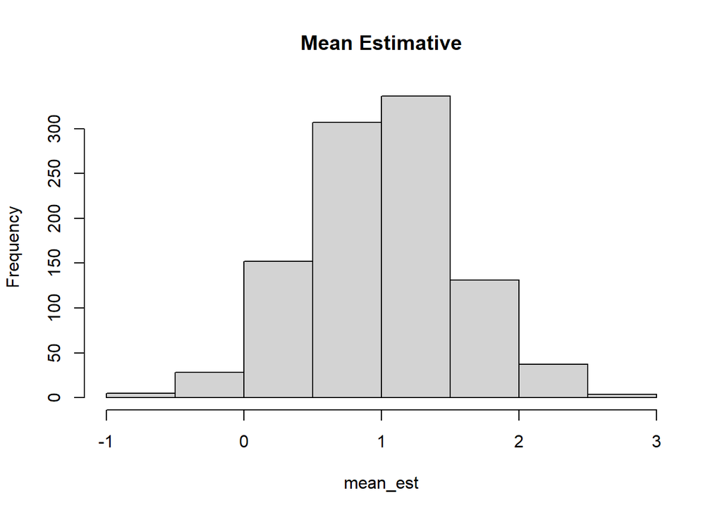

```r
    sampii <- replicate(1000,rnorm(50, 1, 4)) %>% as_tibble()

    f1 <- function(i){
      b <- sampii %>%
        pivot_longer(cols = V1:V1000) %>%
        group_by(name) %>%
        group_nest() %>%
        slice(i) %>%
        unnest() %>%
        dplyr::select(value) %>%
        as_vector()

      R1 <- optim(start, loglike, df = b, method = "BFGS")

      matrix(R1$par, ncol=2)
    }

    R1 <- map(1:1000, f1)
    datah2 <-
      do.call(rbind, R1) %>%
      as_tibble()

    hist(datah2$V1, main = "Mean Estimative", xlab = "mean_est")
```

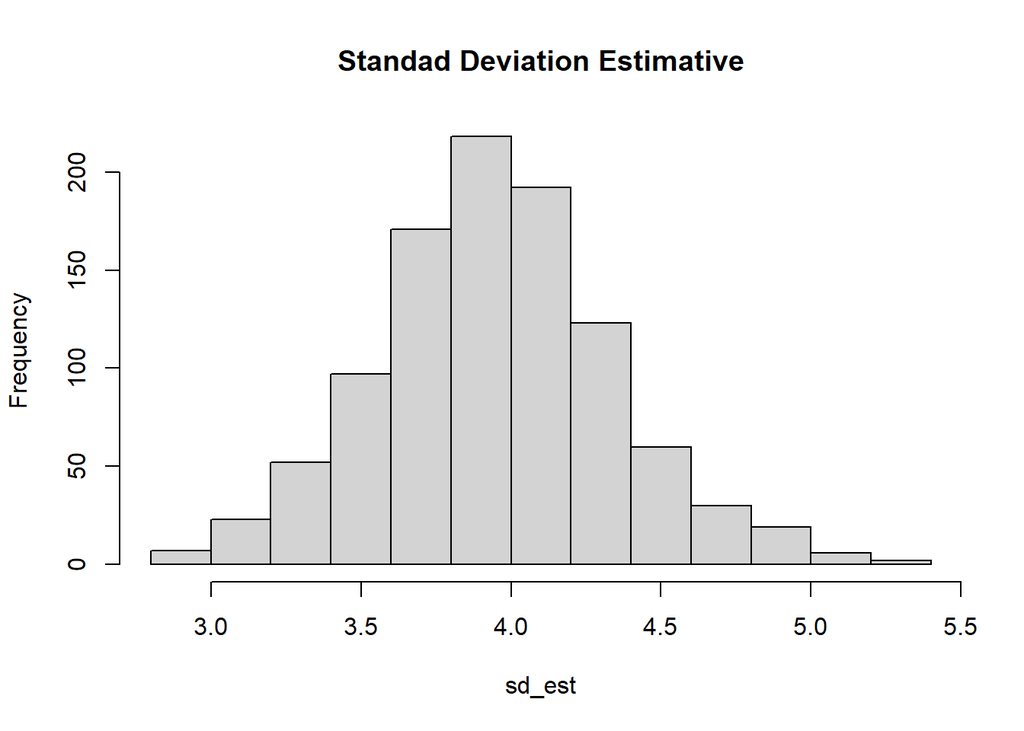

```r
    hist(datah2$V2, main = "Standad Deviation Estimative",
         xlab = "sd_est")
```

```r
    ks.test(datah2, "pnorm", mean(datah2$V1), sd(datah2$V2))
```

```
##
##  Asymptotic one-sample Kolmogorov-Smirnov test
##
## data:  datah2
## D = 0.51627, p-value < 2.2e-16
## alternative hypothesis: two-sided
```

```r
    shapiro.test(datah2$V1)
```

```
##
##  Shapiro-Wilk normality test
##
## data:  datah2$V1
## W = 0.99874, p-value = 0.7146
```

```r
    shapiro.test(datah2$V2)
```

```
##
##  Shapiro-Wilk normality test
##
## data:  datah2$V2
## W = 0.99522, p-value = 0.003142
```

8. Agora crie uma amostra aleatória de 10.000 observações, assuminda a mesma média e desvio-padrão do primeiro item. Estime os parâmetros da média e desvio padrão, bem como os erros-padrão da média e do desvio-padrão estimados para as 50 primeiras observações, depois com as 51 primeiras observações da amostra, e assim por diante até chegar na amostra toda. Guarde os valores em um vetor e faça um gráfico. Descreva o que está acontecendo.

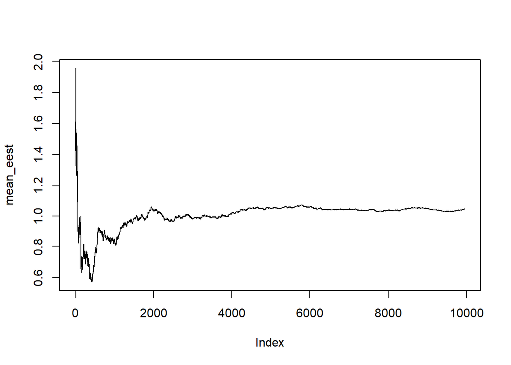

```r
  LN_samp2 <-
      rnorm(10000, 1, 4) %>%
      as_tibble()

    g <- function(x){

      LN_samp2 %>%
        slice(1:x)
      }

    samples_of_obs <- map(50:10000, g)

    h <- function(x){
          a <- optim(start, loglike,
                 df = x%>%as_vector(),
                 method = "BFGS")

          b <- a$par[1]/sqrt(count(x))

          c <- a$par[2]/sqrt(2*(count(x)-1))

          bind_cols(a,b,c)
    }

    eest <- map(samples_of_obs, ~h(.x))

      eests <-
       eest %>%
       bind_rows() %>%
       as_tibble() %>%
       dplyr::select(!convergence) %>%
       group_by(value) %>%
       group_nest() %>%
       pivot_wider(names_from = value,
                   values_from = data) %>%
       dplyr::select(1:9951) %>%
       unnest()

      mean_eest <-
        eests %>%
        dplyr::select(starts_with("par")) %>%
        slice(1) %>%
        as_vector()

      sd_eest <-
        eests %>%
        dplyr::select(starts_with("par")) %>%
        slice(2) %>%
        as_vector()

      ep_mean_eest <-
        eests %>%
        slice(1) %>%
        dplyr::select(starts_with("n...5")) %>%
        as_vector()

      ep_sd_eest <-
        eests %>%
        slice(2) %>%
        dplyr::select(starts_with("n...6")) %>%
        as_vector()

      plot(mean_eest, type = "line")
```

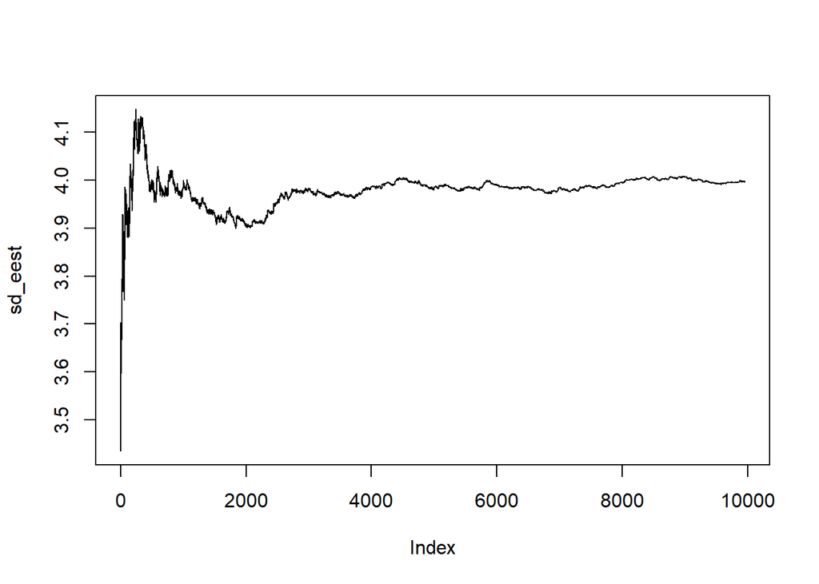

```r
      plot(sd_eest, type = "line")
```

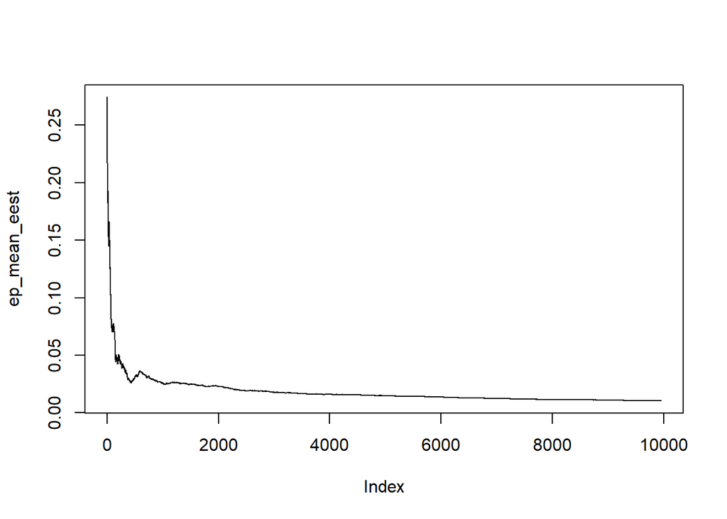

```r
      plot(ep_mean_eest, type = "line")
```

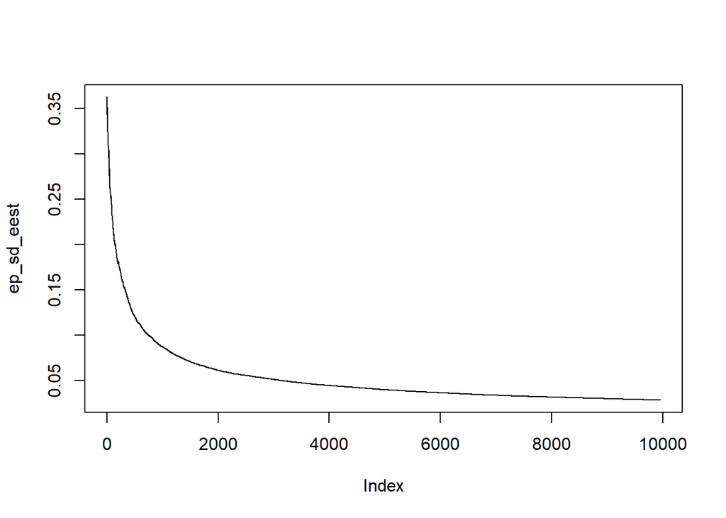

```r
      plot(ep_sd_eest, type = "line")
```

9. Derive a matriz variância-covariância do limite inferior de Cramér-Rao e a avalie nos valores assumidos para gerar os valores aleatórios.

```r
sd=4
mu = 1
n=10000
delmu2 <- -1/(sd^2) * n
deldp2 <-  n/(sd^2) - 3/(sd^4) * sum((LN_samp2 - mu)^2)

I <- -(matrix(c(delmu2, 0, 0, deldp2), nrow = 2, ncol = 2))

vcov_cramer_rao <- solve(I)

vcov_cramer_rao
```

```
##        [,1]        [,2]
## [1,] 0.0016 0.000000000
## [2,] 0.0000 0.000802393
```

10. Os valores estimados com amostras cada vez maiores convergem para o limite inferior de Cramér-Rao?

Estimando a matriz varcovar da amostra com todas as observações, podemos perceber que a diagonal principal da matriz de fato converge para os valores do limite inferior de Cramér-Rao. Além disso, vale lembrar que o estimador de máxima verossimilhança é eficiente para os estimadores e pode atingir o limite inferior.

```r
   m <- optim(start, loglike,
            df = LN_samp2%>%as_vector(),hessian = T,
            method = "BFGS")
   vcov2 <- m$hessian %>% solve()
   vcov2
```

```
##               [,1]          [,2]
## [1,]  1.597234e-03 -1.694763e-10
## [2,] -1.694763e-10  7.990749e-04
```